# Ford GoBike System Dataset Analysis

## by Ajani Ayooluwa

## Investigation Overview

> In this investigation, I wanted to take a look at how customer type, gender, age and start time affect the duration of the trip.

## Dataset Overview

> The dataset consists of information regarding the rides made in a bike-sharing system covering the greater San Francisco Bay area for the month of february in the year 2019. The dataset features include the duration of the trip, the time at which the trip started, the time at which the trip ended, the name of the station at which the passengers embarked and much more.

## Average Trip Duration

> Most trips are a less than 30 minutes long, having a peak at 500 seconds implying that the riders mostly use the bikes to cover relatively short distances.

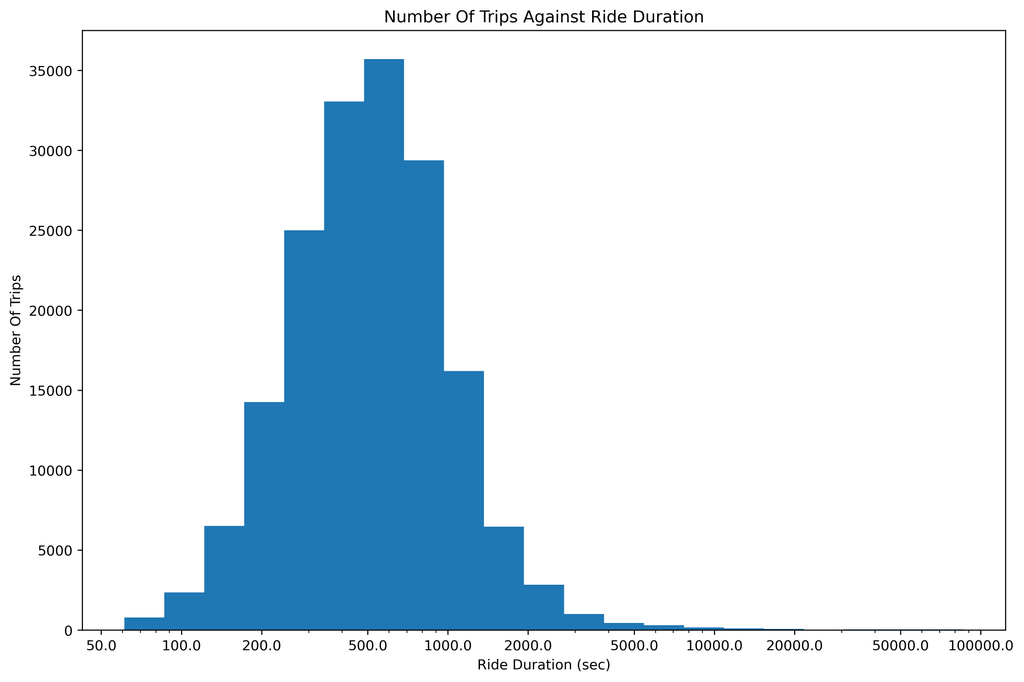

## Age of Members

> A majority of riders are between 18 and 50 years, having the most riders within the ages 27 and 33.

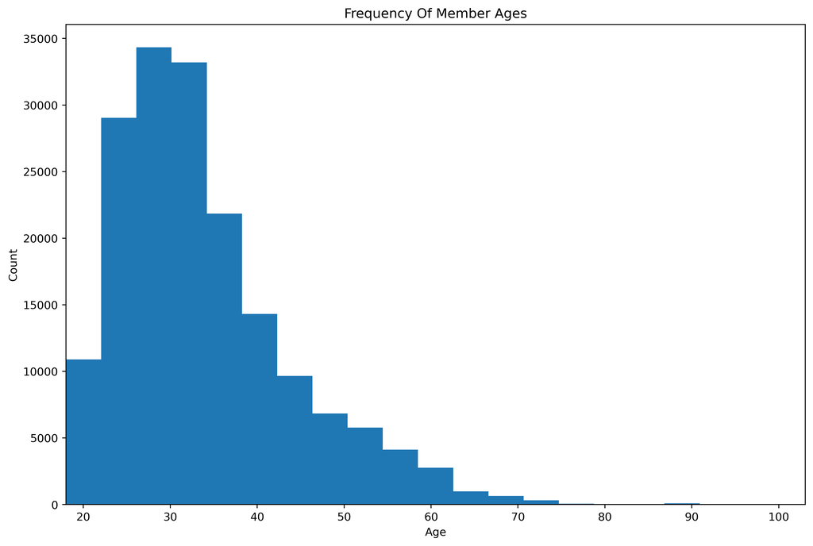

## Trips Taken Per Day

> Most trips were taken on Thursdays and Tuesdays while the Weekends as expected have the least number of trips this maybe be due to fact that most people being spend the weekend resting at home.

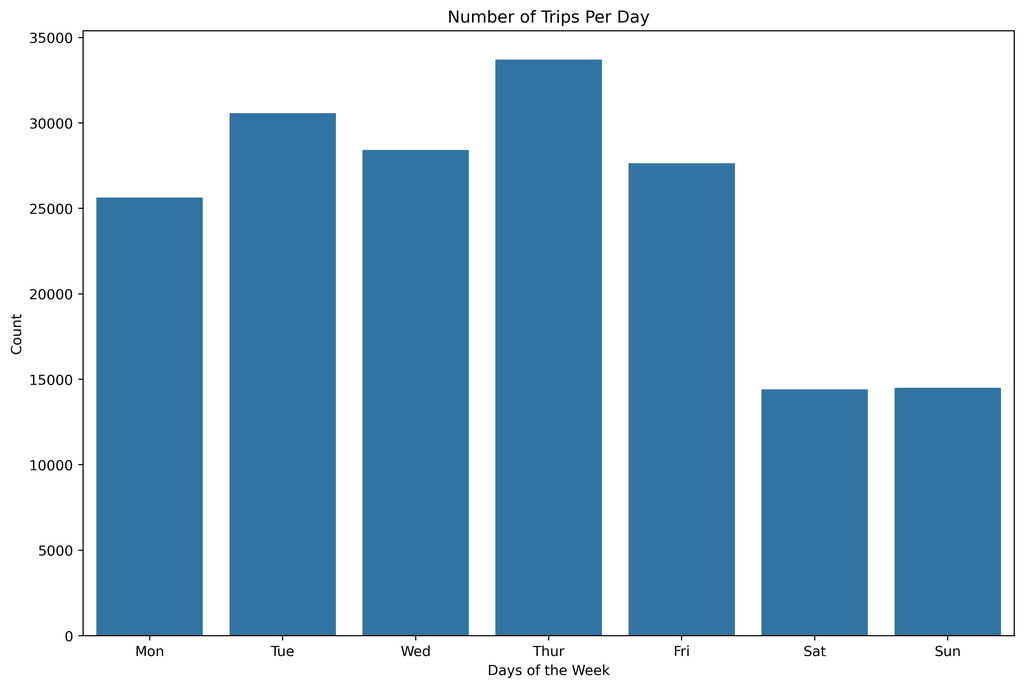

## Trips Taken Per Hour

> The Busiest hours of the day in the morning are 8am and 9am, while in the evening, the busiest hours are 5pm and 6pm.  
> The trend maybe due to the work arrangements of the working class where most people leave in the morning and return in the evening.

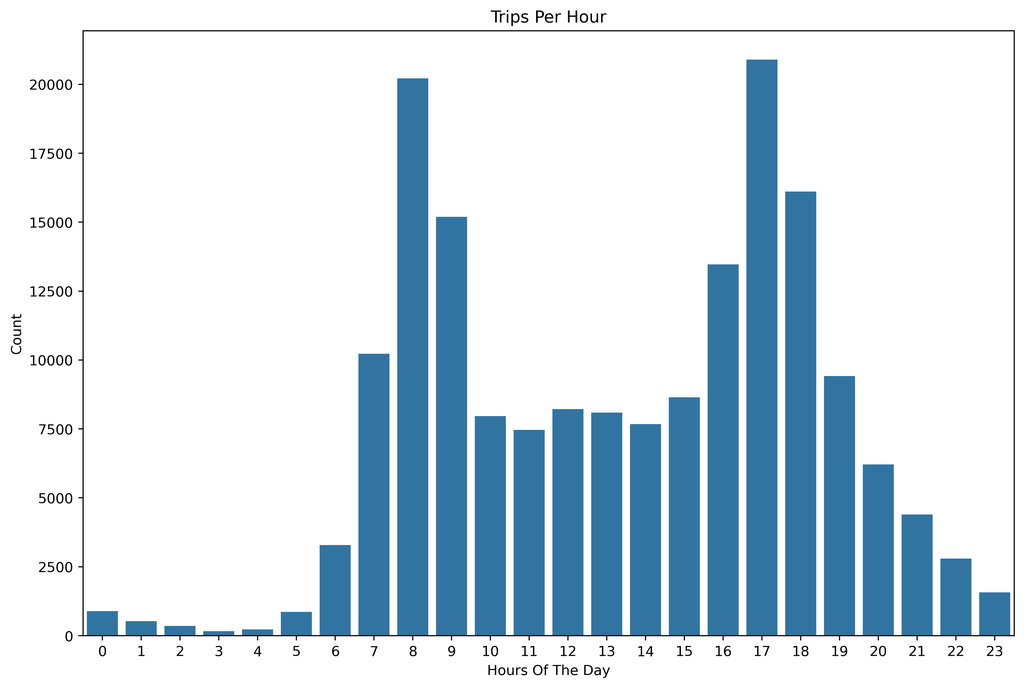

## Distribution Of Trips By User Type.

> There is a huge difference between the number of people who are subscribers and those who are not. It is clear to see that people generally are subcribers. The Subscriber riders took the most trips.

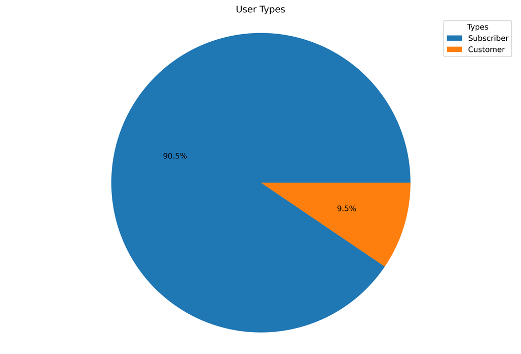

## Average Trip Duration By User Type And Ride Shared

> Although there are more subscribers than customers, the customer riders trips take a longer duration than the subscribers. In addition to that it seems like ride sharing is a feature only available to the subscriber riders.

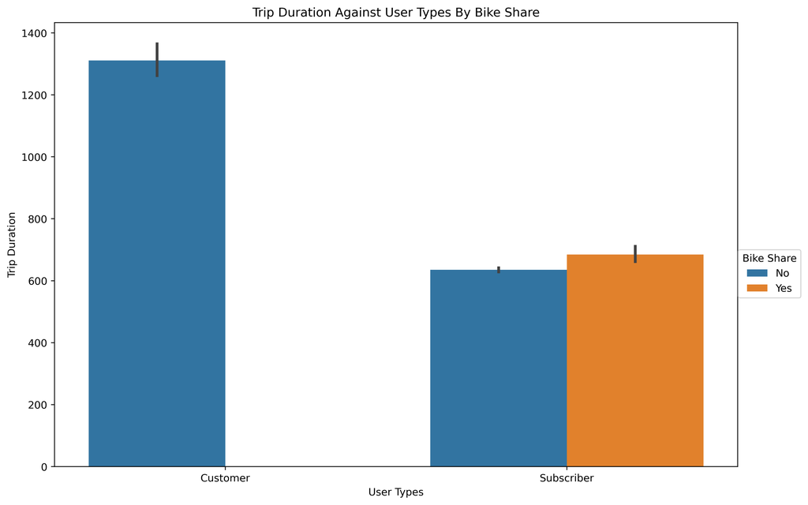

## Average Trip Duration By User Type And Gender

> It can be observed that for both user types, the female riders had longer trip durations than the male riders. For the both user types, the other gender riders take longer trips than their counterparts.

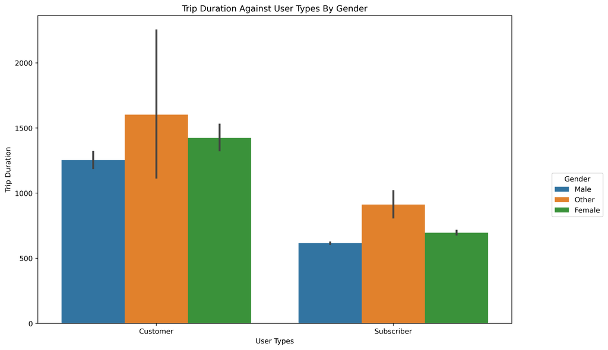